# fitting_linear_regression_two_inputs

## Fitting linear models with 2 inputs

```python
import numpy as np
import pandas as pd
import matplotlib.pyplot as plt

import seaborn as sns
```

```python
import statsmodels.formula.api as smf
```

## Generate our own data

Start with a trend that linearly depends on each input.

$$ \mathrm{trend}_{n} = \beta_0 + \beta_1 x_{n,1} + \beta_2 x_{n,2} $$

Create a grid of input values to help visualize the trend.

```python
x1_values = np.linspace(-3, 3, num=11)
x2_values = np.linspace(-3, 3, num=9)
```

```python
x1_values
```

```
array([-3. , -2.4, -1.8, -1.2, -0.6,  0. ,  0.6,  1.2,  1.8,  2.4,  3. ])
```

```python
input_grid = pd.DataFrame([ (x1, x2) for x1 in x1_values for x2 in x2_values], columns=['x1', 'x2'])
```

```python
input_grid.info()
```

```
<class 'pandas.core.frame.DataFrame'>
RangeIndex: 99 entries, 0 to 98
Data columns (total 2 columns):
 #   Column  Non-Null Count  Dtype
---  ------  --------------  -----
 0   x1      99 non-null     float64
 1   x2      99 non-null     float64
dtypes: float64(2)
memory usage: 1.7 KB
```

```python
input_grid.nunique()
```

```
x1    11
x2     9
dtype: int64
```

Specify the coefficients for the "true trend".

```python
b0 = -0.25
b1 = 1.95
b2 = 0.2
```

```python
data_df = input_grid.copy()
```

```python
data_df['trend'] = b0 + b1 * data_df['x1'] + b2 * data_df['x2']
```

```python
data_df.info()
```

```
<class 'pandas.core.frame.DataFrame'>
RangeIndex: 99 entries, 0 to 98
Data columns (total 3 columns):
 #   Column  Non-Null Count  Dtype
---  ------  --------------  -----
 0   x1      99 non-null     float64
 1   x2      99 non-null     float64
 2   trend   99 non-null     float64
dtypes: float64(3)
memory usage: 2.4 KB
```

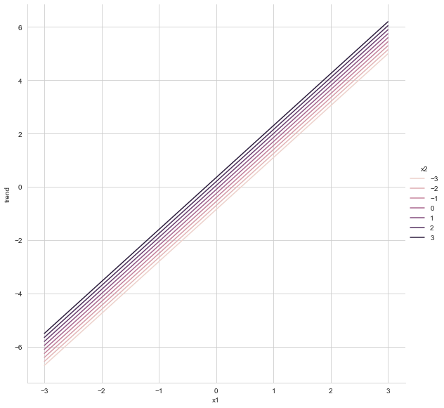

```python
sns.set_style('whitegrid')

sns.relplot(data = data_df, x='x1', y='trend', kind='line', hue='x2',
           estimator=None, units='x2',
           height = 8)

plt.show()
```

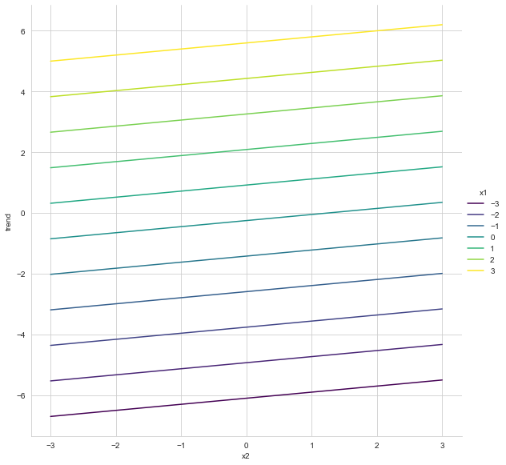

```python
sns.relplot(data = data_df, x='x2', y='trend', kind='line', hue='x1',
           estimator=None, units='x1',
           height = 8,
           palette=sns.color_palette('viridis', as_cmap=True))

plt.show()
```

### What would happen if the slope on `x1` is negative?

What would happen if $\beta_1 < 0$ ?

## Generate some random data

Let's use 35 data points.

```python
N = 35
```

Setup the NumPy random number generator.

```python
rg = np.random.default_rng(2100)
```

Create the inputs as randomly generated from standard normals.

```python
df = pd.DataFrame({'x1': rg.normal(loc = 0, scale = 1, size = N),
                  'x2': rg.normal(loc = 0, scale = 1, size = N)})
```

```python
df.head()
```

|  | x1 | x2 |
| --- | --- | --- |
| 0 | 1.024252 | -0.650623 |
| 1 | -1.733671 | 0.993904 |
| 2 | -0.089294 | 0.251805 |
| 3 | -1.093748 | 1.356543 |
| 4 | 0.320995 | -0.145121 |

```python
df.describe()
```

|  | x1 | x2 |
| --- | --- | --- |
| count | 35.000000 | 35.000000 |
| mean | 0.000014 | 0.251296 |
| std | 0.982505 | 0.963909 |
| min | -1.733671 | -1.813330 |
| 25% | -0.905433 | -0.365161 |
| 50% | -0.089294 | 0.128605 |
| 75% | 0.675610 | 1.024125 |
| max | 1.822354 | 2.538560 |

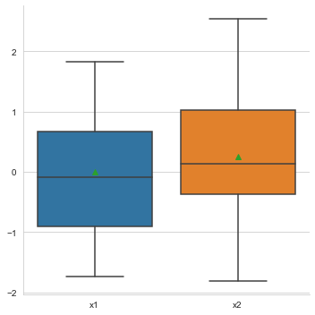

```python
sns.catplot(data = df, kind='box', showmeans=True)

plt.show()
```

Calculate the true trend associated with the response.

```python
df['trend'] = b0 + b1 * df['x1'] + b2 * df['x2']
```

Generate the noisy or random responses around the true trend. Specify the noise level with `sigma_noise`.

```python
sigma_noise = 0.85
```

```python
df['y'] = rg.normal(loc = df.trend.to_numpy(), scale=sigma_noise, size=df.shape[0])
```

```python
df.info()
```

```
<class 'pandas.core.frame.DataFrame'>
RangeIndex: 35 entries, 0 to 34
Data columns (total 4 columns):
 #   Column  Non-Null Count  Dtype
---  ------  --------------  -----
 0   x1      35 non-null     float64
 1   x2      35 non-null     float64
 2   trend   35 non-null     float64
 3   y       35 non-null     float64
dtypes: float64(4)
memory usage: 1.2 KB
```

## Visualize the randomly generated data

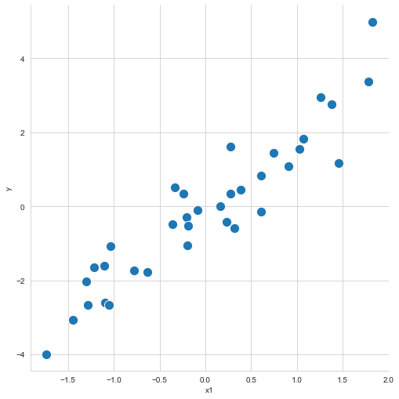

```python
sns.relplot(data = df, x='x1', y='y', s=150, height=7)

plt.show()
```

Fit a trend line with `seaborn`.

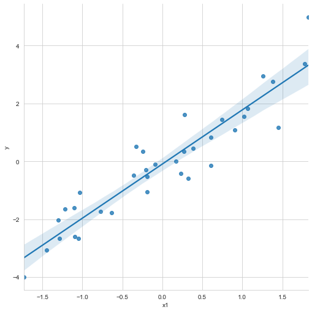

```python
sns.lmplot(data = df, x='x1', y = 'y', height=7)

plt.show()
```

Fit a linear model just considering `x1`.

```python
fit_x1_only = smf.ols(formula = 'y ~ x1', data = df).fit()
```

```python
print( fit_x1_only.summary() )
```

```
                            OLS Regression Results
==============================================================================
Dep. Variable:                      y   R-squared:                       0.873
Model:                            OLS   Adj. R-squared:                  0.869
Method:                 Least Squares   F-statistic:                     226.4
Date:                Thu, 22 Oct 2020   Prob (F-statistic):           2.47e-16
Time:                        19:19:06   Log-Likelihood:                -36.764
No. Observations:                  35   AIC:                             77.53
Df Residuals:                      33   BIC:                             80.64
Df Model:                           1
Covariance Type:            nonrobust
==============================================================================
                 coef    std err          t      P>|t|      [0.025      0.975]
------------------------------------------------------------------------------
Intercept     -0.0909      0.120     -0.755      0.456      -0.336       0.154
x1             1.8711      0.124     15.047      0.000       1.618       2.124
==============================================================================
Omnibus:                        0.685   Durbin-Watson:                   2.313
Prob(Omnibus):                  0.710   Jarque-Bera (JB):                0.475
Skew:                           0.279   Prob(JB):                        0.788
Kurtosis:                       2.882   Cond. No.                         1.03
==============================================================================

Warnings:
[1] Standard Errors assume that the covariance matrix of the errors is correctly specified.
```

Visualize the trend with respect to `x2`.

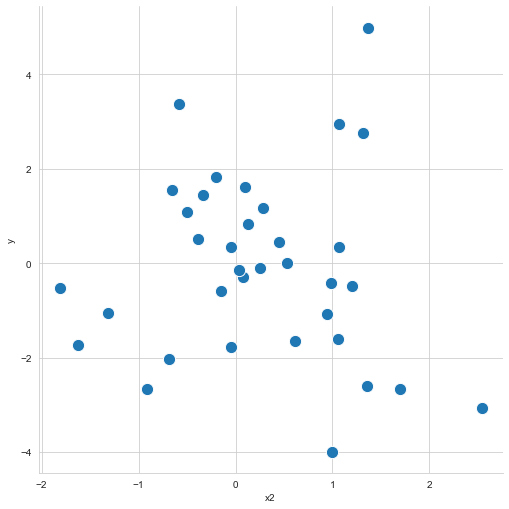

```python
sns.relplot(data = df, x='x2', y='y', s=150, height=7)

plt.show()
```

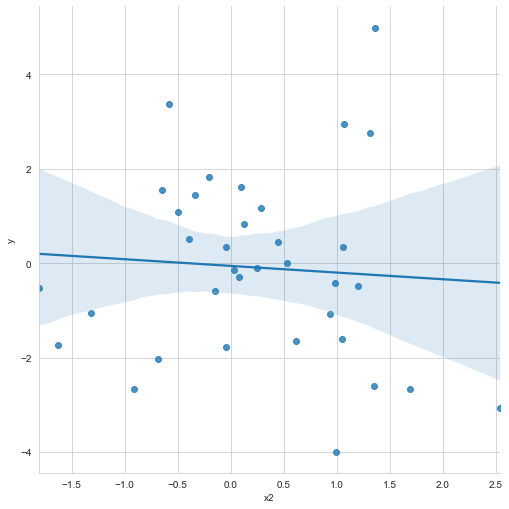

```python
sns.lmplot(data = df, x='x2', y='y', height=7)

plt.show()
```

Fit a model that considers only `x2`.

```python
fit_x2_only = smf.ols(formula = 'y ~ x2', data = df).fit()
```

```python
print( fit_x2_only.summary() )
```

```
                            OLS Regression Results
==============================================================================
Dep. Variable:                      y   R-squared:                       0.005
Model:                            OLS   Adj. R-squared:                 -0.025
Method:                 Least Squares   F-statistic:                    0.1585
Date:                Thu, 22 Oct 2020   Prob (F-statistic):              0.693
Time:                        19:27:02   Log-Likelihood:                -72.764
No. Observations:                  35   AIC:                             149.5
Df Residuals:                      33   BIC:                             152.6
Df Model:                           1
Covariance Type:            nonrobust
==============================================================================
                 coef    std err          t      P>|t|      [0.025      0.975]
------------------------------------------------------------------------------
Intercept     -0.0554      0.348     -0.159      0.875      -0.764       0.653
x2            -0.1412      0.355     -0.398      0.693      -0.862       0.580
==============================================================================
Omnibus:                        1.809   Durbin-Watson:                   1.769
Prob(Omnibus):                  0.405   Jarque-Bera (JB):                1.152
Skew:                           0.442   Prob(JB):                        0.562
Kurtosis:                       3.092   Cond. No.                         1.30
==============================================================================

Warnings:
[1] Standard Errors assume that the covariance matrix of the errors is correctly specified.
```

What about the effect of `x1` and `x2`?

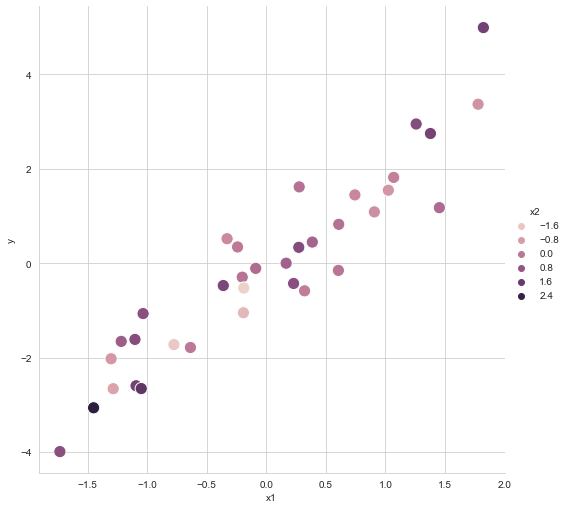

```python
sns.relplot(data = df, x='x1', y ='y', hue='x2', s=150, height=7)

plt.show()
```

Fit an **additive model** between the two inputs, or a **linear additive model**.

```python
df.info()
```

```
<class 'pandas.core.frame.DataFrame'>
RangeIndex: 35 entries, 0 to 34
Data columns (total 4 columns):
 #   Column  Non-Null Count  Dtype
---  ------  --------------  -----
 0   x1      35 non-null     float64
 1   x2      35 non-null     float64
 2   trend   35 non-null     float64
 3   y       35 non-null     float64
dtypes: float64(4)
memory usage: 1.2 KB
```

```python
fit_add = smf.ols(formula = 'y ~ x1 + x2', data = df).fit()
```

```python
print( fit_add.summary() )
```

```
                            OLS Regression Results
==============================================================================
Dep. Variable:                      y   R-squared:                       0.874
Model:                            OLS   Adj. R-squared:                  0.866
Method:                 Least Squares   F-statistic:                     111.1
Date:                Thu, 22 Oct 2020   Prob (F-statistic):           3.96e-15
Time:                        19:32:44   Log-Likelihood:                -36.577
No. Observations:                  35   AIC:                             79.15
Df Residuals:                      32   BIC:                             83.82
Df Model:                           2
Covariance Type:            nonrobust
==============================================================================
                 coef    std err          t      P>|t|      [0.025      0.975]
------------------------------------------------------------------------------
Intercept     -0.1099      0.126     -0.873      0.389      -0.366       0.146
x1             1.8795      0.126     14.867      0.000       1.622       2.137
x2             0.0756      0.129      0.587      0.562      -0.187       0.338
==============================================================================
Omnibus:                        0.363   Durbin-Watson:                   2.319
Prob(Omnibus):                  0.834   Jarque-Bera (JB):                0.321
Skew:                           0.210   Prob(JB):                        0.852
Kurtosis:                       2.791   Cond. No.                         1.33
==============================================================================

Warnings:
[1] Standard Errors assume that the covariance matrix of the errors is correctly specified.
```

Graphically display the coefficient summaries.

We can extract the coefficient estimates and standard errors with:

```python
fit_add.params
```

```
Intercept   -0.109888
x1           1.879500
x2           0.075586
dtype: float64
```

```python
fit_add.bse
```

```
Intercept    0.125869
x1           0.126418
x2           0.128857
dtype: float64
```

```python
type( fit_add.params )
```

```
pandas.core.series.Series
```

```python
fit_add.params.index
```

```
Index(['Intercept', 'x1', 'x2'], dtype='object')
```

```python
def my_coefplot(model_object, figsize_use=(10, 5)):
    fig, ax = plt.subplots(figsize=figsize_use)

    ax.errorbar(x = model_object.params.index,
               y = model_object.params,
               fmt = 'o', color = 'black', ecolor='black',
               yerr = 2 * model_object.bse,
               elinewidth = 3, ms=10)

    ax.axhline(y = 0, linestyle='--', linewidth=5, color='grey')

    ax.set_ylabel('coefficient value')

    plt.show()
```

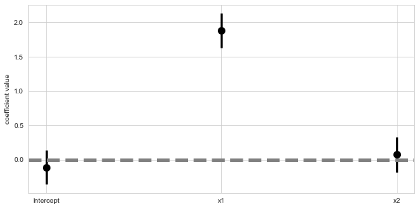

```python
my_coefplot(fit_add)
```

If we want horizontal error bars.

```python
def my_coefplot_h(model_object, figsize_use=(10, 5)):
    fig, ax = plt.subplots(figsize=figsize_use)

    ax.errorbar(y = model_object.params.index,
               x = model_object.params,
               fmt = 'o', color = 'black', ecolor='black',
               xerr = 2 * model_object.bse,
               elinewidth = 3, ms=10)

    ax.axvline(x = 0, linestyle='--', linewidth=5, color='grey')

    ax.set_ylabel('coefficient value')

    plt.show()
```

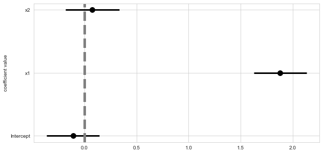

```python
my_coefplot_h(fit_add)
```

## Model "fitted values"

```python
type( fit_add.fittedvalues )
```

```
pandas.core.series.Series
```

```python
df['fitted'] = fit_add.fittedvalues
```

```python
df.describe()
```

|  | x1 | x2 | trend | y | fitted |
| --- | --- | --- | --- | --- | --- |
| count | 35.000000 | 35.000000 | 35.000000 | 35.000000 | 35.000000 |
| mean | 0.000014 | 0.251296 | -0.199713 | -0.090867 | -0.090867 |
| std | 0.982505 | 0.963909 | 1.903734 | 1.967794 | 1.839800 |
| min | -1.733671 | -1.813330 | -3.431878 | -3.988479 | -3.293198 |
| 25% | -0.905433 | -0.365161 | -2.019651 | -1.633558 | -1.823781 |
| 50% | -0.089294 | 0.128605 | -0.373762 | -0.150161 | -0.258682 |
| 75% | 0.675610 | 1.024125 | 1.046430 | 1.133126 | 1.151981 |
| max | 1.822354 | 2.538560 | 3.576082 | 4.991517 | 3.418209 |

The predicted vs observed figure.

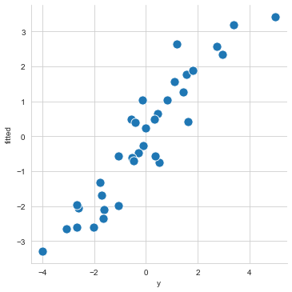

```python
sns.relplot(data = df, x='y', y='fitted', s=125)

plt.show()
```

Add in a "45-degree" line.

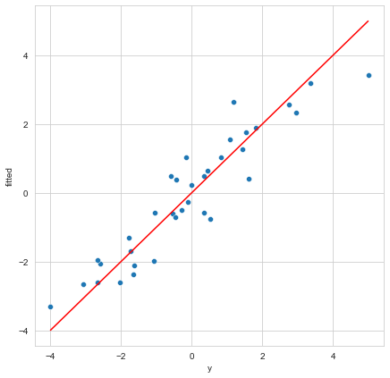

```python
fig, ax = plt.subplots(figsize=(7,7))

sns.scatterplot(data = df, x='y', y='fitted')

sns.lineplot(data = df, x='y', y='y', color='red')

plt.show()
```

Another regression performance metric is R-squared.

```python
fit_add.rsquared
```

```
0.8741420863007204
```

```python
df.head()
```

|  | x1 | x2 | trend | y | fitted |
| --- | --- | --- | --- | --- | --- |
| 0 | 1.024252 | -0.650623 | 1.617167 | 1.547730 | 1.766016 |
| 1 | -1.733671 | 0.993904 | -3.431878 | -3.988479 | -3.293198 |
| 2 | -0.089294 | 0.251805 | -0.373762 | -0.107839 | -0.258682 |
| 3 | -1.093748 | 1.356543 | -2.111500 | -2.594083 | -2.063052 |
| 4 | 0.320995 | -0.145121 | 0.346917 | -0.583119 | 0.482454 |

```python
df.loc[:, ['y', 'fitted']].corr()
```

|  | y | fitted |
| --- | --- | --- |
| y | 1.000000 | 0.934956 |
| fitted | 0.934956 | 1.000000 |

```python
df.loc[:, ['y', 'fitted']].corr().iloc[0, 1] ** 2
```

```
0.8741420863007208
```

Compare to the model with just `x2`. Make this figure with matplotlib.

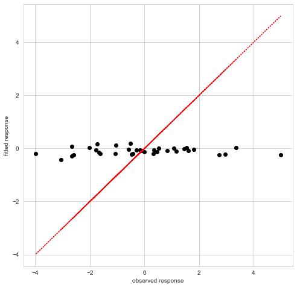

```python
fig, ax = plt.subplots(figsize = (8,8))

ax.plot(df.y, fit_x2_only.fittedvalues, 'ko')
ax.plot(df.y, df.y, 'r:')

ax.set_xlabel('observed response')
ax.set_ylabel('fitted response')

plt.show()
```

```python
fit_x2_only.rsquared
```

```
0.004781362406604872
```

## Behavior of the residuals

```python
df.head()
```

|  | x1 | x2 | trend | y | fitted |
| --- | --- | --- | --- | --- | --- |
| 0 | 1.024252 | -0.650623 | 1.617167 | 1.547730 | 1.766016 |
| 1 | -1.733671 | 0.993904 | -3.431878 | -3.988479 | -3.293198 |
| 2 | -0.089294 | 0.251805 | -0.373762 | -0.107839 | -0.258682 |
| 3 | -1.093748 | 1.356543 | -2.111500 | -2.594083 | -2.063052 |
| 4 | 0.320995 | -0.145121 | 0.346917 | -0.583119 | 0.482454 |

```python
fit_add.resid
```

```
0    -0.218286
1    -0.695282
2     0.150844
3    -0.531031
4    -1.065573
5     0.490993
6    -0.030881
7     1.279827
8    -0.416000
9    -0.065349
10    0.190682
11   -0.060414
12   -0.475802
13    0.699255
14   -0.241077
```

[output cut: 21 more lines]

```python
df['residual'] = fit_add.resid
```

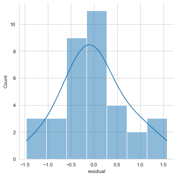

```python
sns.displot(data = df, x = 'residual', kde=True)

plt.show()
```

QQplot to examine how the residuals line up with the theoretical Gaussian behavior.

For now, we will instead study the trend or variation in the residual with respect to the input.

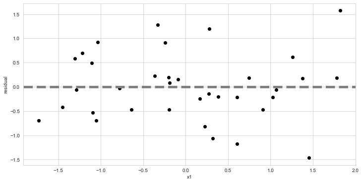

```python
fig, ax = plt.subplots(figsize=(12, 6))

ax.plot(df.x1, fit_add.resid, 'ko')
ax.axhline(y = 0, linestyle='--', linewidth=5, color='grey')

ax.set_xlabel('x1')
ax.set_ylabel('residual')

plt.show()
```

## Graphically study behavior with statsmodels

```python
import statsmodels.api as sm
```

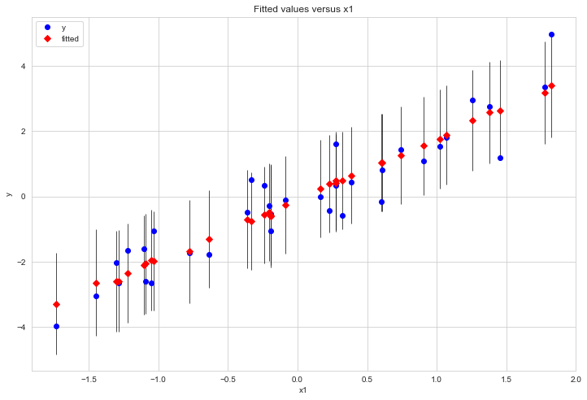

```python
fig, ax = plt.subplots(figsize=(12,8))

fig = sm.graphics.plot_fit(fit_add, 'x1', ax=ax)

plt.show()
```

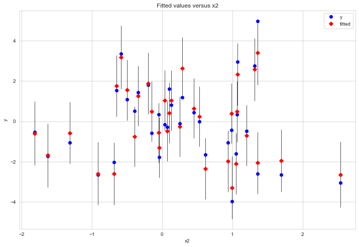

```python
fig, ax = plt.subplots(figsize=(12,8))

fig = sm.graphics.plot_fit(fit_add, 'x2', ax=ax)

plt.show()
```

### Partial regression plots

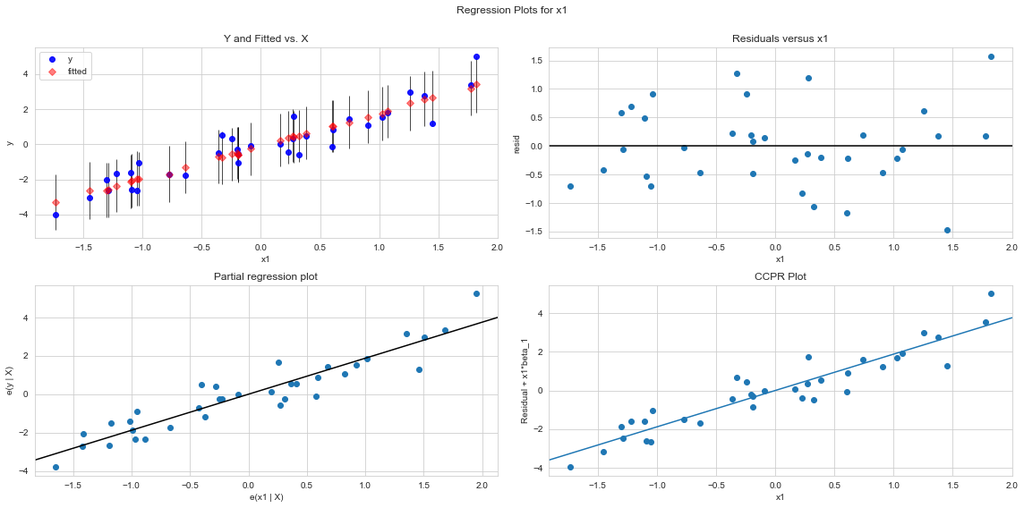

```python
fig = plt.figure(figsize=(16, 8))

sm.graphics.plot_regress_exog(fit_add, 'x1', fig=fig)

plt.show()
```

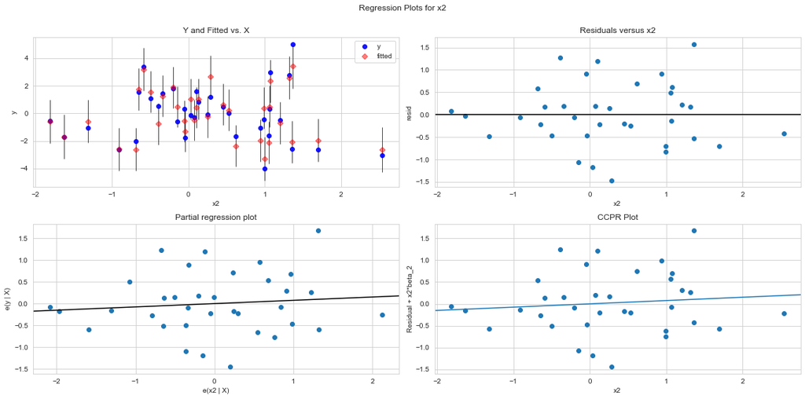

```python
fig = plt.figure(figsize=(16, 8))

sm.graphics.plot_regress_exog(fit_add, 'x2', fig=fig)

plt.show()
```

Plot all partial regression plots together in a grid.

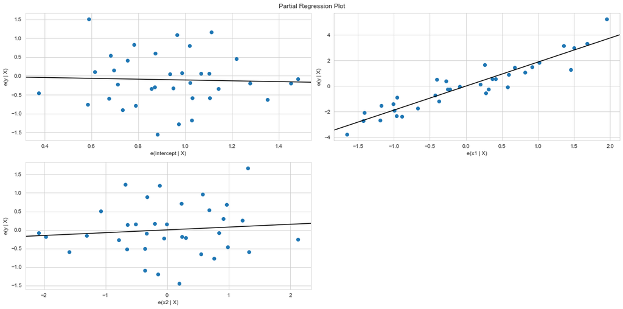

```python
fig = plt.figure(figsize=(16,8))

sm.graphics.plot_partregress_grid(fit_add, fig=fig)

plt.show()
```

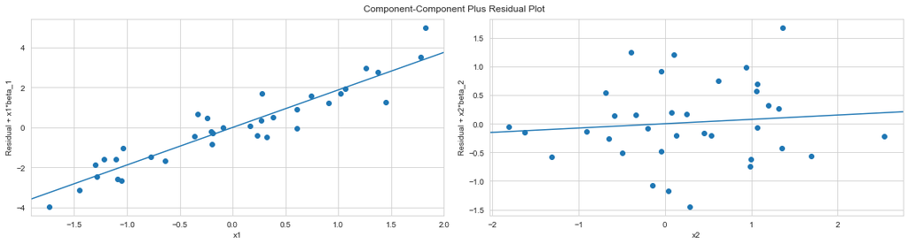

```python
fig = plt.figure(figsize=(16,8))

sm.graphics.plot_ccpr_grid(fit_add, fig=fig)

plt.show()
```

## Interaction between two inputs

$$ \mathrm{trend}_{n} = \beta_0 + \beta_1 x_{n,1} + \beta_2 x_{n,2} + \beta_3 x_{n,1} x_{n,2} $$

If we defined the product term as $x_{n,3} = x_{n,1} x_{n,2}$ and rewrote the trend as:

$$ \mathrm{trend}_{n} = \beta_0 + \beta_1 x_{n,1} + \beta_2 x_{n,2} + \beta_3 x_{n,3} $$

This fact holds regardless of our features. For example, the following is also a linear model:

$$ \mathrm{trend}_{n} = \beta_0 + \beta_1 x_{n,1} + \beta_2 x_{n,2} + \beta_3 x_{n,1} x_{n,2} + \beta_4 x_{n,1}^{2} + \beta_5 x_{n,2}^2 $$

Let's generate some data which comes from interactions.

```python
rg = np.random.default_rng(2100)

df2 = pd.DataFrame({'x1': rg.normal(loc = 0, scale = 1, size = N),
                   'x2': rg.normal(loc = 0, scale = 1, size = N)})

# calculate the trend where the interaction term is b3
b3 = 1.5
df2['trend'] = b0 + b1 * df2['x1'] + b2 * df2['x2'] + b3 * df2['x1'] * df2['x2']

# generate teh noisy observations

df2['y'] = rg.normal(loc = df2.trend.to_numpy(), scale=sigma_noise, size=df2.shape[0])
```

```python
df2.head()
```

|  | x1 | x2 | trend | y |
| --- | --- | --- | --- | --- |
| 0 | 1.024252 | -0.650623 | 0.617564 | 0.548127 |
| 1 | -1.733671 | 0.993904 | -6.016530 | -6.573132 |
| 2 | -0.089294 | 0.251805 | -0.407488 | -0.141566 |
| 3 | -1.093748 | 1.356543 | -4.337073 | -4.819656 |
| 4 | 0.320995 | -0.145121 | 0.277042 | -0.652994 |

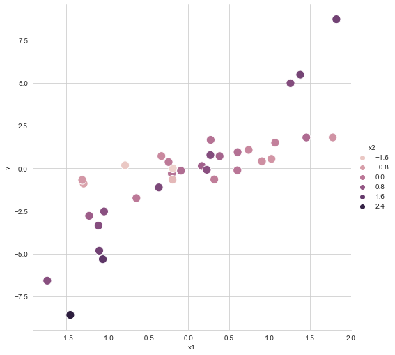

```python
sns.relplot(data = df2, x='x1', y = 'y', hue='x2', s=150, height=7)

plt.show()
```

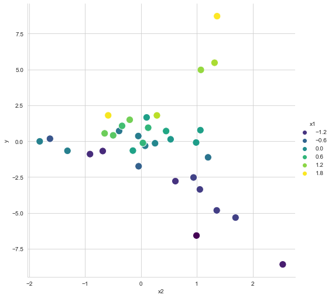

```python
sns.relplot(data = df2, x='x2', y = 'y', hue='x1', s=150, height=7,
           palette=sns.color_palette('viridis', as_cmap=True))

plt.show()
```

```python
fit_interact = smf.ols(formula = 'y ~ x1 * x2', data = df2).fit()
```

```python
print( fit_interact.summary() )
```

```
                            OLS Regression Results
==============================================================================
Dep. Variable:                      y   R-squared:                       0.958
Model:                            OLS   Adj. R-squared:                  0.954
Method:                 Least Squares   F-statistic:                     233.8
Date:                Thu, 22 Oct 2020   Prob (F-statistic):           2.30e-21
Time:                        20:49:43   Log-Likelihood:                -34.349
No. Observations:                  35   AIC:                             76.70
Df Residuals:                      31   BIC:                             82.92
Df Model:                           3
Covariance Type:            nonrobust
==============================================================================
                 coef    std err          t      P>|t|      [0.025      0.975]
------------------------------------------------------------------------------
Intercept     -0.1073      0.120     -0.894      0.378      -0.352       0.137
x1             1.7486      0.136     12.823      0.000       1.470       2.027
x2             0.1749      0.132      1.325      0.195      -0.094       0.444
x1:x2          1.7649      0.129     13.668      0.000       1.502       2.028
==============================================================================
Omnibus:                        0.099   Durbin-Watson:                   2.090
Prob(Omnibus):                  0.952   Jarque-Bera (JB):                0.313
Skew:                           0.036   Prob(JB):                        0.855
Kurtosis:                       2.542   Cond. No.                         1.98
==============================================================================

Warnings:
[1] Standard Errors assume that the covariance matrix of the errors is correctly specified.
```

```python
fit_product_only = smf.ols(formula = 'y ~ x1:x2', data = df2).fit()
```

```python
print( fit_product_only.summary() )
```

```
                            OLS Regression Results
==============================================================================
Dep. Variable:                      y   R-squared:                       0.726
Model:                            OLS   Adj. R-squared:                  0.717
Method:                 Least Squares   F-statistic:                     87.30
Date:                Thu, 22 Oct 2020   Prob (F-statistic):           8.62e-11
Time:                        20:50:35   Log-Likelihood:                -67.053
No. Observations:                  35   AIC:                             138.1
Df Residuals:                      33   BIC:                             141.2
Df Model:                           1
Covariance Type:            nonrobust
==============================================================================
                 coef    std err          t      P>|t|      [0.025      0.975]
------------------------------------------------------------------------------
Intercept      0.0069      0.287      0.024      0.981      -0.578       0.592
x1:x2          2.4397      0.261      9.344      0.000       1.908       2.971
==============================================================================
Omnibus:                        0.981   Durbin-Watson:                   1.509
Prob(Omnibus):                  0.612   Jarque-Bera (JB):                0.238
Skew:                           0.062   Prob(JB):                        0.888
Kurtosis:                       3.385   Cond. No.                         1.14
==============================================================================

Warnings:
[1] Standard Errors assume that the covariance matrix of the errors is correctly specified.
```

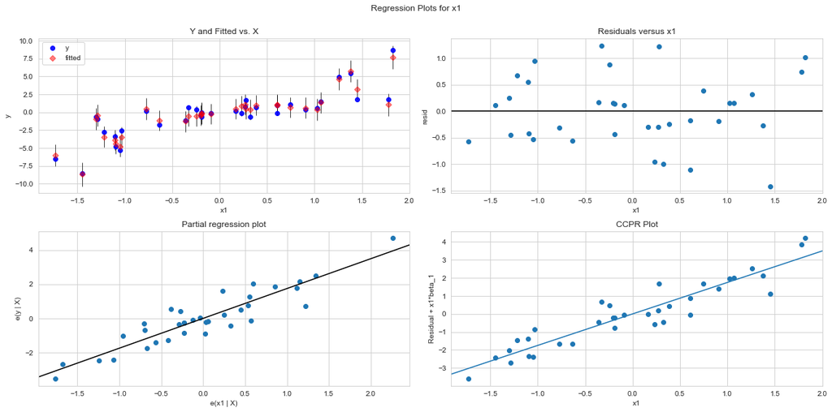

```python
fig = plt.figure(figsize=(16,8))

sm.graphics.plot_regress_exog(fit_interact, 'x1', fig=fig)

plt.show()
```

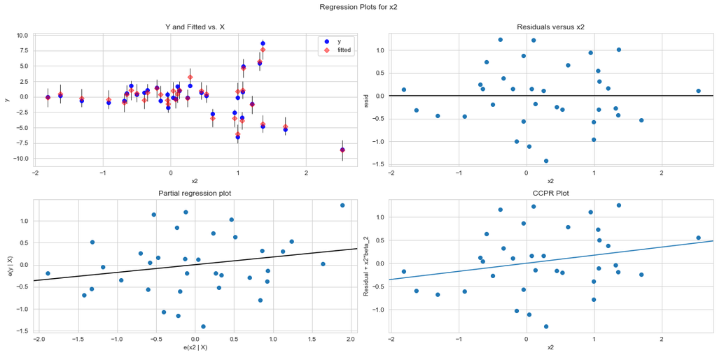

```python
fig = plt.figure(figsize=(16,8))

sm.graphics.plot_regress_exog(fit_interact, 'x2', fig=fig)

plt.show()
```

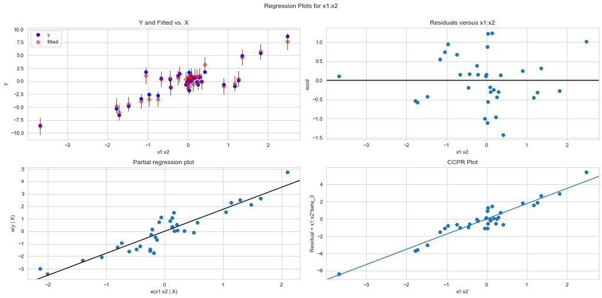

```python
fig = plt.figure(figsize=(16,8))

sm.graphics.plot_regress_exog(fit_interact, 'x1:x2', fig=fig)

plt.show()
```

What if we tried out a quadratic model with respect to x2?

```python
fit_quad_x2 = smf.ols(formula = 'y ~ x2 + np.power(x2, 2)', data=df2).fit()
```

```python
print( fit_quad_x2.summary() )
```

```
                            OLS Regression Results
==============================================================================
Dep. Variable:                      y   R-squared:                       0.161
Model:                            OLS   Adj. R-squared:                  0.109
Method:                 Least Squares   F-statistic:                     3.069
Date:                Thu, 22 Oct 2020   Prob (F-statistic):             0.0603
Time:                        20:54:11   Log-Likelihood:                -86.619
No. Observations:                  35   AIC:                             179.2
Df Residuals:                      32   BIC:                             183.9
Df Model:                           2
Covariance Type:            nonrobust
===================================================================================
                      coef    std err          t      P>|t|      [0.025      0.975]
-----------------------------------------------------------------------------------
Intercept           0.6612      0.635      1.041      0.306      -0.633       1.955
x2                 -0.4116      0.567     -0.725      0.474      -1.567       0.744
np.power(x2, 2)    -0.8334      0.419     -1.991      0.055      -1.686       0.019
==============================================================================
Omnibus:                       19.547   Durbin-Watson:                   1.781
Prob(Omnibus):                  0.000   Jarque-Bera (JB):               30.158
Skew:                           1.428   Prob(JB):                     2.83e-07
Kurtosis:                       6.539   Cond. No.                         2.47
==============================================================================

Warnings:
[1] Standard Errors assume that the covariance matrix of the errors is correctly specified.
```

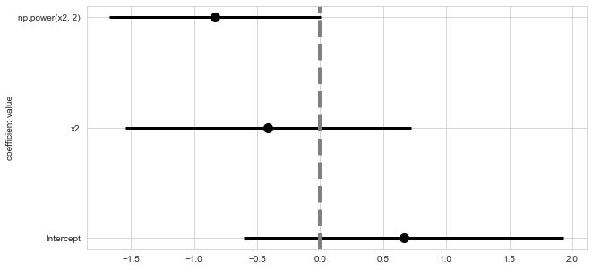

```python
my_coefplot_h(fit_quad_x2)
```

```python
fit_higher_order = smf.ols(formula = 'y ~ x2 + np.power(x2, 2) + np.power(x2, 3) + np.power(x2, 4)', data=df2).fit()
```

```python
print( fit_higher_order.summary() )
```

```
                            OLS Regression Results
==============================================================================
Dep. Variable:                      y   R-squared:                       0.221
Model:                            OLS   Adj. R-squared:                  0.117
Method:                 Least Squares   F-statistic:                     2.130
Date:                Thu, 22 Oct 2020   Prob (F-statistic):              0.102
Time:                        20:55:08   Log-Likelihood:                -85.315
No. Observations:                  35   AIC:                             180.6
Df Residuals:                      30   BIC:                             188.4
Df Model:                           4
Covariance Type:            nonrobust
===================================================================================
                      coef    std err          t      P>|t|      [0.025      0.975]
-----------------------------------------------------------------------------------
Intercept           0.1024      0.761      0.135      0.894      -1.452       1.657
x2                 -0.1075      1.331     -0.081      0.936      -2.826       2.611
np.power(x2, 2)     0.3037      1.256      0.242      0.811      -2.262       2.869
np.power(x2, 3)    -0.0955      0.573     -0.167      0.869      -1.265       1.074
np.power(x2, 4)    -0.2136      0.321     -0.666      0.510      -0.869       0.441
==============================================================================
Omnibus:                       11.083   Durbin-Watson:                   1.833
Prob(Omnibus):                  0.004   Jarque-Bera (JB):               14.035
Skew:                           0.811   Prob(JB):                     0.000896
Kurtosis:                       5.645   Cond. No.                         28.7
==============================================================================

Warnings:
[1] Standard Errors assume that the covariance matrix of the errors is correctly specified.
```